# R Notebook

Now we’ll go back to CI creation in the normal fashion. We’ll take the ames data from the CIs lab earlier today and regard it now as a sample, we won’t be drawing any smaller samples from within it. This is the usual situation in an analysis: you use all the data available to you!

1.Load the data again, clean_names(), and re-familiarise yourself with it

```r
library(tidyverse)
library(infer)
library(janitor)
```

```r
names(ames)
```

```
 [1] "order"           "pid"             "ms_sub_class"
 [4] "ms_zoning"       "lot_frontage"    "lot_area"
 [7] "street"          "alley"           "lot_shape"
[10] "land_contour"    "utilities"       "lot_config"
[13] "land_slope"      "neighborhood"    "condition_1"
[16] "condition_2"     "bldg_type"       "house_style"
[19] "overall_qual"    "overall_cond"    "year_built"
[22] "year_remod_add"  "roof_style"      "roof_matl"
[25] "exterior_1st"    "exterior_2nd"    "mas_vnr_type"
[28] "mas_vnr_area"    "exter_qual"      "exter_cond"
[31] "foundation"      "bsmt_qual"       "bsmt_cond"
[34] "bsmt_exposure"   "bsmt_fin_type_1" "bsmt_fin_sf_1"
[37] "bsmt_fin_type_2" "bsmt_fin_sf_2"   "bsmt_unf_sf"
[40] "total_bsmt_sf"   "heating"         "heating_qc"
[43] "central_air"     "electrical"      "x1st_flr_sf"
[46] "x2nd_flr_sf"     "low_qual_fin_sf" "gr_liv_area"
[49] "bsmt_full_bath"  "bsmt_half_bath"  "full_bath"
[52] "half_bath"       "bedroom_abv_gr"  "kitchen_abv_gr"
[55] "kitchen_qual"    "tot_rms_abv_grd" "functional"
[58] "fireplaces"      "fireplace_qu"    "garage_type"
[61] "garage_yr_blt"   "garage_finish"   "garage_cars"
[64] "garage_area"     "garage_qual"     "garage_cond"
[67] "paved_drive"     "wood_deck_sf"    "open_porch_sf"
[70] "enclosed_porch"  "x3ssn_porch"     "screen_porch"
[73] "pool_area"       "pool_qc"         "fence"
[76] "misc_feature"    "misc_val"        "mo_sold"
[79] "yr_sold"         "sale_type"       "sale_condition"
[82] "sale_price"
```

2. Investigate the distribution of lot_area. Is the distribution roughly normal? If not, what problems do you find? Ans : Plot a histogram of lot_area. Is the distribution normal? Also calculate the mean

```r
mean(ames$lot_area)
```

```
[1] 10147.92
```

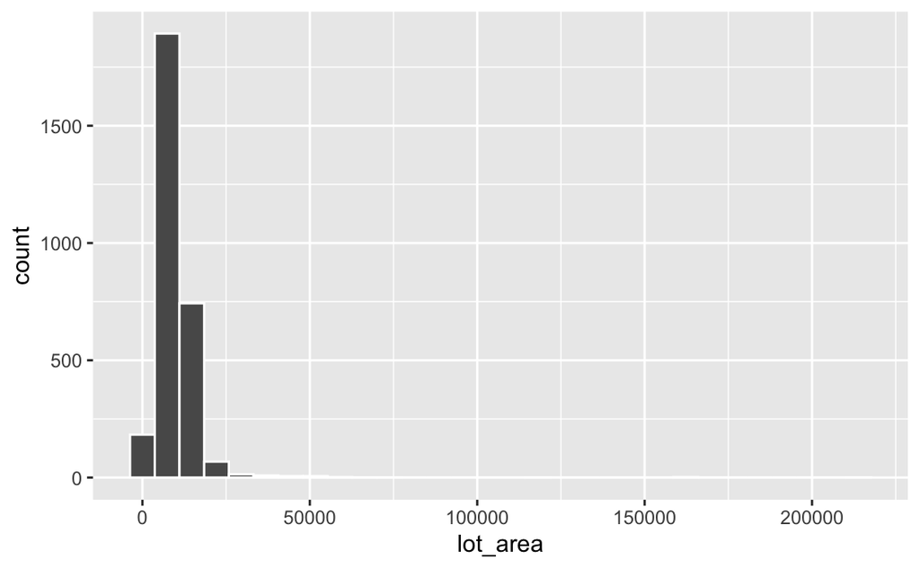

```r
ames %>%
  ggplot(aes(x = lot_area)) +
  geom_histogram(col = "white")
```

It is not normal, It looks Right Skewed

3.Compute and visualise a bootstrap sampling distribution for the mean(lot_area) of the sold houses.

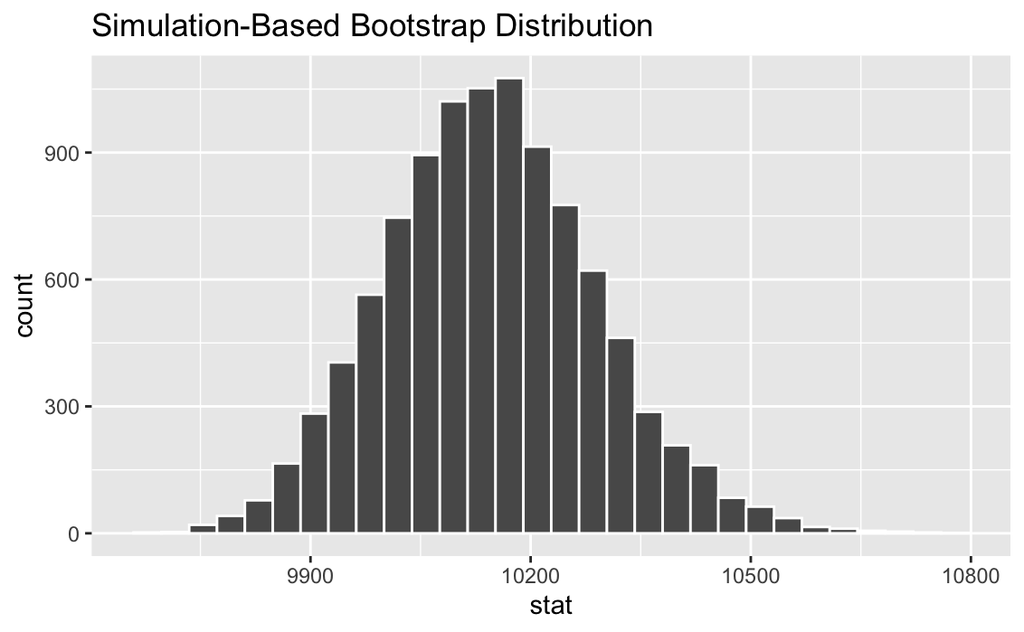

```r
bootstrap_distribution <- ames %>%
  specify(response = lot_area) %>%
  generate(reps = 10000, type = "bootstrap") %>%
  calculate(stat = "mean")

bootstrap_distribution %>%
  visualise(bins = 30)
```

4. Use your bootstrap distribution to calculate a 95% CI for mean(lot_area), and visualise it on the distribution

```r
bootstrap_ci <- bootstrap_distribution %>%
  get_confidence_interval(level = 0.95, type = "percentile")
bootstrap_ci
```

| 2.5% | 97.5% |
| --- | --- |
| 9875.125 | 10447.98 |

step b : now visualising them

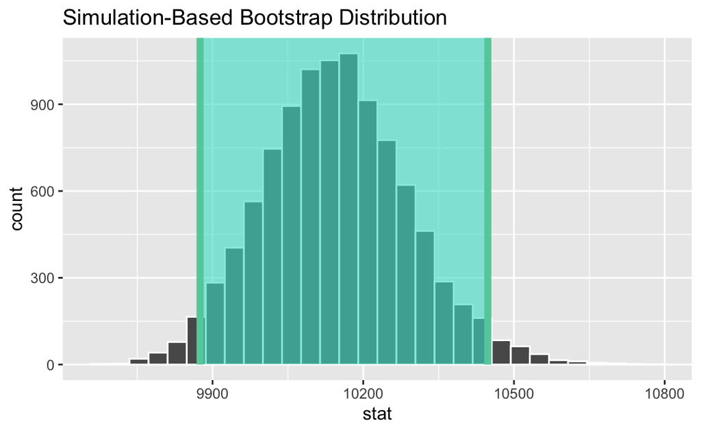

```r
bootstrap_distribution %>%
  visualise(bins = 30) +
  shade_confidence_interval(endpoints = bootstrap_ci)
```

You would like to know the mean(lot_area) of the sold houses with higher confidence. Calculate the 99% CI for this variable (you can re-use your bootstrap distribution from above). Is it narrower or broader than the 95% CI? Does that make sense?

```r
bootstrap_ci_99 <- bootstrap_distribution %>%
  get_confidence_interval(level = 0.99, type = "percentile")
bootstrap_ci_99
```

| 0.5% | 99.5% |
| --- | --- |
| 9799.82 | 10558.36 |

now lets visualise it

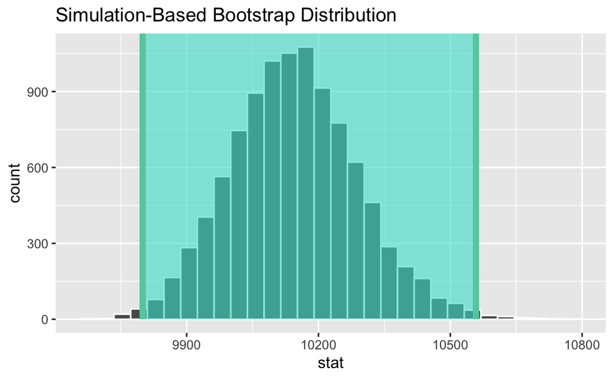

```r
bootstrap_distribution %>%
  visualise(bins = 30) +
  shade_confidence_interval(endpoints = bootstrap_ci_99)
```

Calculate the point estimate of the mean(lot_area)

```r
bootstrap_distribution %>%
  summarise(mean(stat))
```

| mean(stat) |
| --- |
| 10146.05 |